# Project: Investigate Movies Dataset

- Introduction
- Import Packages
- Data Wrangling
- Exploratory Data Analysis
- Conclusions

## Introduction

I will analys Movies data set tmdb-movies.csv

This data set contains information about 10,000 movies collected from The Movie Database (TMDb), including user ratings and revenue. ● Certain columns, like ‘cast’ and ‘genres’, contain multiple values separated by pipe (|)characters.  
Goal:\ analyzing this amazing dataset and find intersting factes What makes a profitable movie?\ get some interesting statistical insights\ Answer some questions like The most commonly produced genres? \ What month has the most content added?\ Most Movie Runtime ? , Explore Movies characteristics before and after 2000?

Starting By wrangle and clean the dataset. then visualize the findings.

## websites I used

https://www.kaggle.com/ , https://seaborn.pydata.org/ , https://stackoverflow.com/ ,https://pandas.pydata.org/

### import all of the packages

```python
import pandas as pd
%matplotlib inline
import seaborn as sns
import matplotlib.pyplot as plt
```

## Data Wrangling

In this section , We will load the data, check for cleanliness, and then trim and clean our dataset for analysis.

```python
data = pd.read_csv('tmdb-movies.csv')
```

### 1. Display Top 5 Rows of The Dataset

```python
data.head()
```

|  | id | imdb_id | popularity | budget | revenue | original_title | cast | homepage | director | tagline | ... | overview | runtime | genres | production_companies | release_date | vote_count | vote_average | release_year | budget_adj | revenue_adj |
| --- | --- | --- | --- | --- | --- | --- | --- | --- | --- | --- | --- | --- | --- | --- | --- | --- | --- | --- | --- | --- | --- |
| 0 | 135397 | tt0369610 | 32.985763 | 150000000 | 1513528810 | Jurassic World | Chris Pratt\|Bryce Dallas Howard\|Irrfan Khan\|Vi... | http://www.jurassicworld.com/ | Colin Trevorrow | The park is open. | ... | Twenty-two years after the events of Jurassic ... | 124 | Action\|Adventure\|Science Fiction\|Thriller | Universal Studios\|Amblin Entertainment\|Legenda... | 6/9/15 | 5562 | 6.5 | 2015 | 1.379999e+08 | 1.392446e+09 |
| 1 | 76341 | tt1392190 | 28.419936 | 150000000 | 378436354 | Mad Max: Fury Road | Tom Hardy\|Charlize Theron\|Hugh Keays-Byrne\|Nic... | http://www.madmaxmovie.com/ | George Miller | What a Lovely Day. | ... | An apocalyptic story set in the furthest reach... | 120 | Action\|Adventure\|Science Fiction\|Thriller | Village Roadshow Pictures\|Kennedy Miller Produ... | 5/13/15 | 6185 | 7.1 | 2015 | 1.379999e+08 | 3.481613e+08 |
| 2 | 262500 | tt2908446 | 13.112507 | 110000000 | 295238201 | Insurgent | Shailene Woodley\|Theo James\|Kate Winslet\|Ansel... | http://www.thedivergentseries.movie/#insurgent | Robert Schwentke | One Choice Can Destroy You | ... | Beatrice Prior must confront her inner demons ... | 119 | Adventure\|Science Fiction\|Thriller | Summit Entertainment\|Mandeville Films\|Red Wago... | 3/18/15 | 2480 | 6.3 | 2015 | 1.012000e+08 | 2.716190e+08 |
| 3 | 140607 | tt2488496 | 11.173104 | 200000000 | 2068178225 | Star Wars: The Force Awakens | Harrison Ford\|Mark Hamill\|Carrie Fisher\|Adam D... | http://www.starwars.com/films/star-wars-episod... | J.J. Abrams | Every generation has a story. | ... | Thirty years after defeating the Galactic Empi... | 136 | Action\|Adventure\|Science Fiction\|Fantasy | Lucasfilm\|Truenorth Productions\|Bad Robot | 12/15/15 | 5292 | 7.5 | 2015 | 1.839999e+08 | 1.902723e+09 |
| 4 | 168259 | tt2820852 | 9.335014 | 190000000 | 1506249360 | Furious 7 | Vin Diesel\|Paul Walker\|Jason Statham\|Michelle ... | http://www.furious7.com/ | James Wan | Vengeance Hits Home | ... | Deckard Shaw seeks revenge against Dominic Tor... | 137 | Action\|Crime\|Thriller | Universal Pictures\|Original Film\|Media Rights ... | 4/1/15 | 2947 | 7.3 | 2015 | 1.747999e+08 | 1.385749e+09 |

5 rows × 21 columns

### 2. Find Shape of Our Dataset (Number of Rows And Number of Columns)

```python
data.shape
print("Number of Rows",data.shape[0])
print("Number of Columns",data.shape[1])
```

```
Number of Rows 10866
Number of Columns 21
```

### 3. Getting Information About Our Dataset Like Total Number Rows, Total Number of Columns, Datatypes of Each Column And Memory Requirement

```python
data.info();
```

```
<class 'pandas.core.frame.DataFrame'>
RangeIndex: 10866 entries, 0 to 10865
Data columns (total 21 columns):
 #   Column                Non-Null Count  Dtype
---  ------                --------------  -----
 0   id                    10866 non-null  int64
 1   imdb_id               10856 non-null  object
 2   popularity            10866 non-null  float64
 3   budget                10866 non-null  int64
 4   revenue               10866 non-null  int64
 5   original_title        10866 non-null  object
 6   cast                  10790 non-null  object
 7   homepage              2936 non-null   object
 8   director              10822 non-null  object
 9   tagline               8042 non-null   object
 10  keywords              9373 non-null   object
 11  overview              10862 non-null  object
 12  runtime               10866 non-null  int64
 13  genres                10843 non-null  object
 14  production_companies  9836 non-null   object
 15  release_date          10866 non-null  object
 16  vote_count            10866 non-null  int64
 17  vote_average          10866 non-null  float64
 18  release_year          10866 non-null  int64
 19  budget_adj            10866 non-null  float64
 20  revenue_adj           10866 non-null  float64
dtypes: float64(4), int64(6), object(11)
memory usage: 1.7+ MB
```

## 4. Check Null Values In The Dataset

```python
data.isnull().sum()
```

```
id                         0
imdb_id                   10
popularity                 0
budget                     0
revenue                    0
original_title             0
cast                      76
homepage                7930
director                  44
tagline                 2824
keywords                1493
overview                   4
runtime                    0
genres                    23
production_companies    1030
release_date               0
vote_count                 0
vote_average               0
release_year               0
budget_adj                 0
revenue_adj                0
dtype: int64
```

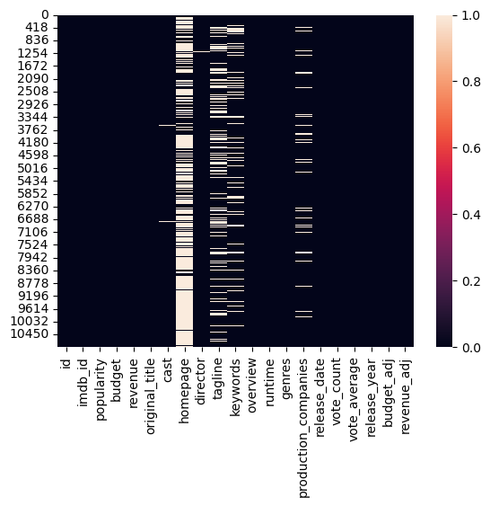

```python
sns.heatmap(data.isnull())
plt.show()
```

```python
per_missing = data.isnull().sum() * 100 / len(data)
per_missing
```

```
id                       0.000000
imdb_id                  0.092030
popularity               0.000000
budget                   0.000000
revenue                  0.000000
original_title           0.000000
cast                     0.699429
homepage                72.979937
director                 0.404933
tagline                 25.989324
keywords                13.740107
overview                 0.036812
runtime                  0.000000
genres                   0.211669
production_companies     9.479109
release_date             0.000000
vote_count               0.000000
vote_average             0.000000
release_year             0.000000
budget_adj               0.000000
revenue_adj              0.000000
dtype: float64
```

## 5. Drop All The Missing Values and unneeded columns

```python
data.columns
```

```
Index(['id', 'imdb_id', 'popularity', 'budget', 'revenue', 'original_title',
       'cast', 'homepage', 'director', 'tagline', 'keywords', 'overview',
       'runtime', 'genres', 'production_companies', 'release_date',
       'vote_count', 'vote_average', 'release_year', 'budget_adj',
       'revenue_adj'],
      dtype='object')
```

```python
data.drop(['homepage','tagline','id','imdb_id','keywords','overview','production_companies','budget_adj','revenue_adj'], axis = 1,inplace = True)
```

check for any null values

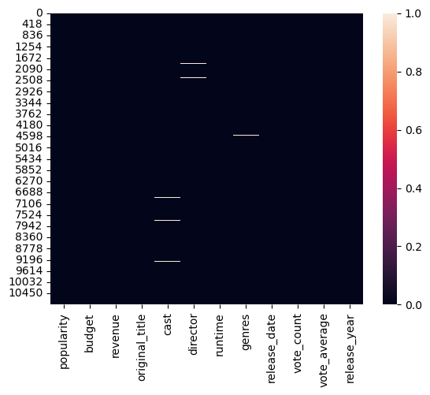

```python
sns.heatmap(data.isnull())
plt.show()
```

```python
data.shape
```

```
(10866, 12)
```

```python
data.isnull().sum()
```

```
popularity         0
budget             0
revenue            0
original_title     0
cast              76
director          44
runtime            0
genres            23
release_date       0
vote_count         0
vote_average       0
release_year       0
dtype: int64
```

#### Then drop the rest of rows with missing data

```python
data.dropna(inplace = True)
data.isnull().sum()
```

```
popularity        0
budget            0
revenue           0
original_title    0
cast              0
director          0
runtime           0
genres            0
release_date      0
vote_count        0
vote_average      0
release_year      0
dtype: int64
```

## 6. Check For Duplicate Data

```python
data.drop_duplicates(inplace =True)
dup_data=data.duplicated().any()

print("Are there any duplicated values in data?",dup_data)
```

```
Are there any duplicated values in data? False
```

```python
data.shape
```

```
(10731, 12)
```

## Creat Profit column

```python
data['profit'] = data.revenue - data.budget
data['profit']
```

```
0        1363528810
1         228436354
2         185238201
3        1868178225
4        1316249360
            ...
10861             0
10862             0
10863             0
10864             0
10865        -19000
Name: profit, Length: 10731, dtype: int64
```

```python
data.rename(columns ={'release_year' : 'year' ,"original_title" :"title"} ,inplace = True)
data.columns
```

```
Index(['popularity', 'budget', 'revenue', 'title', 'cast', 'director',
       'runtime', 'genres', 'release_date', 'vote_count', 'vote_average',
       'year', 'profit'],
      dtype='object')
```

## Exploratory Data Analysis

## 8. Get Overall Statistics About The DataFrame

```python
data.describe()
```

|  | popularity | budget | revenue | runtime | vote_count | vote_average | year | profit |
| --- | --- | --- | --- | --- | --- | --- | --- | --- |
| count | 10731.000000 | 1.073100e+04 | 1.073100e+04 | 10731.000000 | 10731.000000 | 10731.000000 | 10731.000000 | 1.073100e+04 |
| mean | 0.652615 | 1.480365e+07 | 4.031989e+07 | 102.468829 | 219.812972 | 5.964710 | 2001.259622 | 2.551624e+07 |
| std | 1.004804 | 3.106456e+07 | 1.176524e+08 | 30.493873 | 578.815324 | 0.930283 | 12.820151 | 9.715071e+07 |
| min | 0.000188 | 0.000000e+00 | 0.000000e+00 | 0.000000 | 10.000000 | 1.500000 | 1960.000000 | -4.139124e+08 |
| 25% | 0.210765 | 0.000000e+00 | 0.000000e+00 | 90.000000 | 17.000000 | 5.400000 | 1995.000000 | 0.000000e+00 |
| 50% | 0.387081 | 0.000000e+00 | 0.000000e+00 | 99.000000 | 39.000000 | 6.000000 | 2006.000000 | 0.000000e+00 |
| 75% | 0.720889 | 1.600000e+07 | 2.500000e+07 | 112.000000 | 148.000000 | 6.600000 | 2011.000000 | 9.971094e+06 |
| max | 32.985763 | 4.250000e+08 | 2.781506e+09 | 900.000000 | 9767.000000 | 9.200000 | 2015.000000 | 2.544506e+09 |

## >>>>>>>>>>>>>>>>>>>>>>>>>>>>>>>>>>>>>>>>>>>>>>>>>>>>>>>>>>

## from this slight statistics

1- there is a postive correlation between budget spend and revenue?\ 2-Its weird to have a movie with 0 run tim and 0 budget as well as revenue

## >>>>>>>>>>>>>>>>>>>>>>>>>>>>>>>>>>>>>>>>>>>>>>>>>>>>>>>>>>

## fill 0 values in columns

```python
data.runtime = data.runtime.replace(0 ,data.runtime.median())
data.budget = data.budget.replace(0 ,data.budget.mean())
data.revenue = data.revenue.replace(0 ,data.revenue.mean())
```

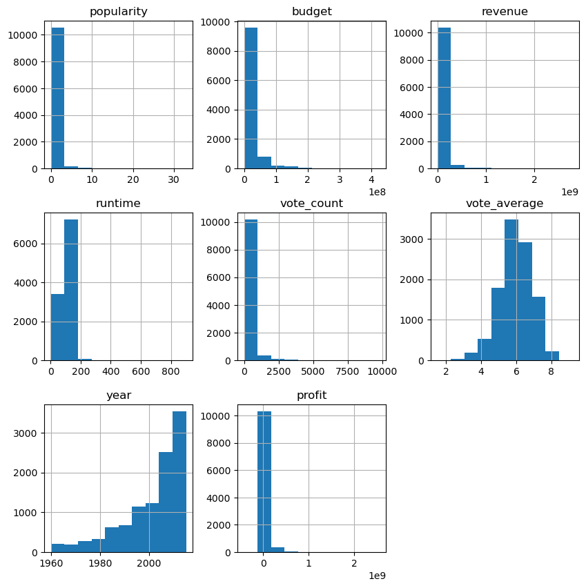

```python
data.hist(figsize =(10,10));
```

## >>>>>>>>>>>>>>>>>>>>>>>>>>>>>>>>>>>>>>>>>>>>>>>>>>>>>>>>>>

## from this hist

1-vote_average has normal Distribution (Mean =Median) </br> 2- year has Skewed left that means (Mean < Median) </br> 3 - popularity , budget , revenue , profit has Skewed right that means (Mean > Median)

## >>>>>>>>>>>>>>>>>>>>>>>>>>>>>>>>>>>>>>>>>>>>>>>>>>>>>>>>>>

```python
data.describe()
```

|  | popularity | budget | revenue | runtime | vote_count | vote_average | year | profit |
| --- | --- | --- | --- | --- | --- | --- | --- | --- |
| count | 10731.000000 | 1.073100e+04 | 1.073100e+04 | 10731.000000 | 10731.000000 | 10731.000000 | 10731.000000 | 1.073100e+04 |
| mean | 0.652615 | 2.249862e+07 | 6.244304e+07 | 102.727146 | 219.812972 | 5.964710 | 2001.259622 | 2.551624e+07 |
| std | 1.004804 | 2.814008e+07 | 1.116267e+08 | 30.040664 | 578.815324 | 0.930283 | 12.820151 | 9.715071e+07 |
| min | 0.000188 | 1.000000e+00 | 2.000000e+00 | 3.000000 | 10.000000 | 1.500000 | 1960.000000 | -4.139124e+08 |
| 25% | 0.210765 | 1.480365e+07 | 4.024287e+07 | 90.000000 | 17.000000 | 5.400000 | 1995.000000 | 0.000000e+00 |
| 50% | 0.387081 | 1.480365e+07 | 4.031989e+07 | 99.000000 | 39.000000 | 6.000000 | 2006.000000 | 0.000000e+00 |
| 75% | 0.720889 | 1.600000e+07 | 4.031989e+07 | 112.000000 | 148.000000 | 6.600000 | 2011.000000 | 9.971094e+06 |
| max | 32.985763 | 4.250000e+08 | 2.781506e+09 | 900.000000 | 9767.000000 | 9.200000 | 2015.000000 | 2.544506e+09 |

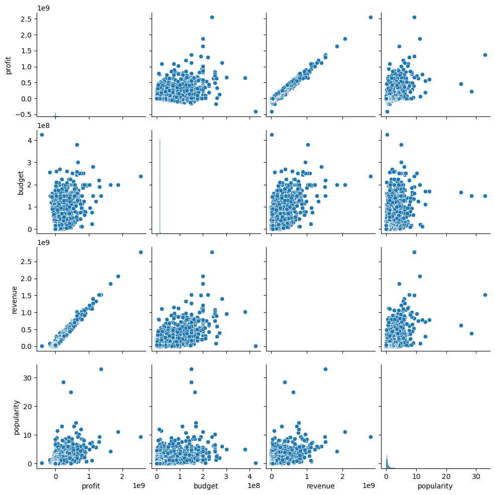

```python
sns.pairplot(data [['profit' ,'budget' ,'revenue' ,'popularity']]);
```

## >>>>>>>>>>>>>>>>>>>>>>>>>>>>>>>>>>>>>>>>>>>>>>>>>>>>>>>>>>

There is a positive correlation between </br> 1 - profit and these variables(budget and revenue and popularity) its very strong with revenue

2 - revenue (budget ,popularity)

3 -popularity and budget

## >>>>>>>>>>>>>>>>>>>>>>>>>>>>>>>>>>>>>>>>>>>>>>>>>>>>>>>>>>

## 'Which Month are the Most Movies added?

```python
data['release_date'] = pd.to_datetime(data['release_date'])
data['month'] = data['release_date'].dt.month_name(locale='English')
```

```python
movies_month =data['month'].value_counts().sort_values(ascending =False)
```

```python
movies_month
```

```
September    1319
October      1138
December      974
August        906
January       892
June          822
March         813
May           807
November      798
April         791
July          790
February      681
Name: month, dtype: int64
```

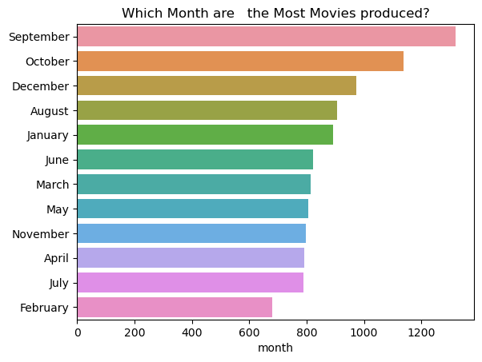

```python
sns.barplot(x =movies_month , y= movies_month.index );
plt.title('Which Month are   the Most Movies produced?')
```

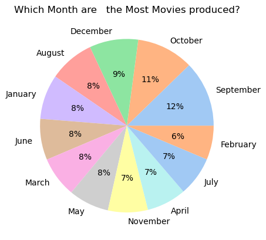

```python
colors = sns.color_palette('pastel')[0:12]
plt.pie(movies_month ,labels =movies_month.index ,colors = colors, autopct='%.0f%%');
plt.title('Which Month are   the Most Movies produced?')
```

## >>>>>>>>>>>>>>>>>>>>>>>>>>>>>>>>>>>>>>>>>>>>>>>>>>>>>>>>>>

in september and October

</br> the most months produced films by 12% and 11%)

## >>>>>>>>>>>>>>>>>>>>>>>>>>>>>>>>>>>>>>>>>>>>>>>>>>>>>>>>>>

## Top release_years

```python
top_release_years =data['year'].value_counts().sort_values(ascending =False).head(15)
```

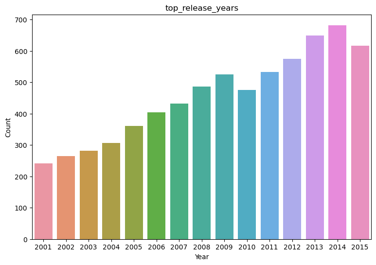

```python
plt.figure(figsize=(9, 6))
sns.barplot(x=top_release_years.index, y=top_release_years.values)
plt.xlabel('Year')
plt.ylabel('Count')
plt.title('top_release_years')
plt.show()
```

## >>>>>>>>>>>>>>>>>>>>>>>>>>>>>>>>>>>>>>>>>>>>>>>>>

in 2014 ,2013

</br> are the most two years produced Movies

## >>>>>>>>>>>>>>>>>>>>>>>>>>>>>>>>>>>>>>>>>>>>>>>>>>>>>

Top 5 Movie Having Runtime

```python
top_time =data.nlargest(5,'runtime')[['title','year','runtime']].set_index('title')
top_time
```

| title | year | runtime |
| --- | --- | --- |
| The Story of Film: An Odyssey | 2011 | 900 |
| Taken | 2002 | 877 |
| Band of Brothers | 2001 | 705 |
| Shoah | 1985 | 566 |
| Planet Earth | 2006 | 550 |

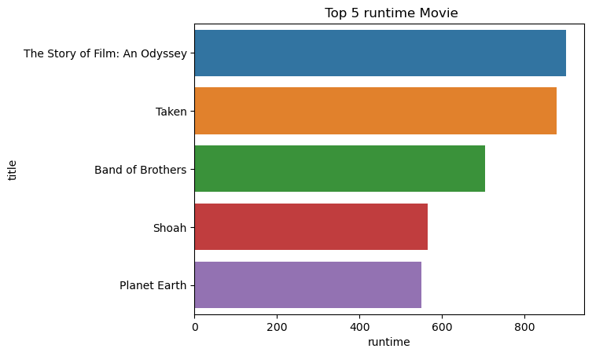

```python
sns.barplot(x =top_time['runtime'] ,y = top_time.index );
plt.title(' Top 5 runtime Movie');
```

## >>>>>>>>>>>>>>>>>>>>>>>>>>>>>>>>>>>>>>>>>>>>>>>>>>>>>>>>>>

The Story of Film: An Odyssey Movie

</br> in 2011 is the longest runtime movie by 900 min

## >>>>>>>>>>>>>>>>>>>>>>>>>>>>>>>>>>>>>>>>>>>>>>>>>>>>>>>>>>

## Number of Movies Per Year

```python
nu_year = data.year.value_counts()
```

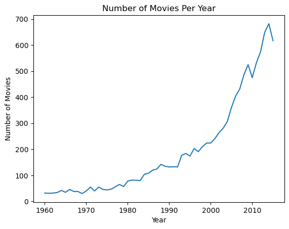

```python
sns.lineplot(x=nu_year.index,y=nu_year)
plt.title('Number of Movies Per Year')
plt.xlabel('Year')
plt.ylabel('Number of Movies');
```

## >>>>>>>>>>>>>>>>>>>>>>>>>>>>>>>>>>>>>>>>>>>>>>>>>>>>>>>>>>

Positive correlation

</br> Between the years and Number of movies specially after 2000

## >>>>>>>>>>>>>>>>>>>>>>>>>>>>>>>>>>>>>>>>>>>>>>>>>>>>>>>>>>

## Top 5 Popular Movies ?

```python
top_5_Popular= data.nlargest(5,'popularity')[['title','year','popularity']].set_index('title')
```

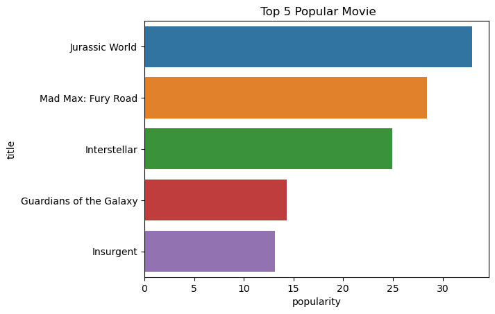

```python
 sns.barplot(x =top_5_Popular['popularity'] ,y = top_5_Popular.index );
plt.title(' Top 5 Popular Movie');
```

## >>>>>>>>>>>>>>>>>>>>>>>>>>>>>>>>>>>>>>>>>>>>>>>>>>>>>>>>>>

Jurassic World Movie in 2015 is the most popular movie by 32.985763

## >>>>>>>>>>>>>>>>>>>>>>>>>>>>>>>>>>>>>>>>>>>>>>>>>>>>>>>>>>

## Top 5 Highest profit Movies

```python
top_5_revenue = data.nlargest(5,'profit')[['title','year','profit']].set_index('title')
```

[output not shown]

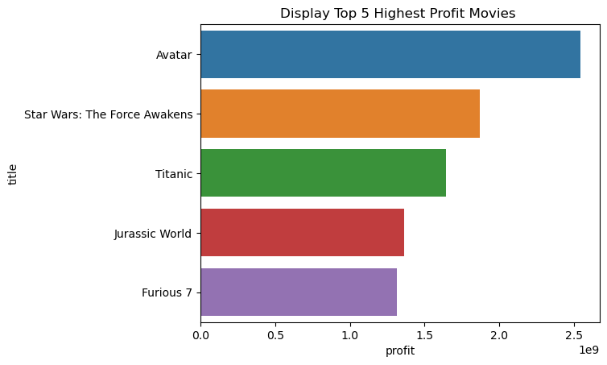

```python
sns.barplot(top_5_revenue['profit'],top_5_revenue.index)
plt.title("Display Top 5 Highest Profit Movies ");
```

## >>>>>>>>>>>>>>>>>>>>>>>>>>>>>>>>>>>>>>>>>>>>>>>>>>

Avatar

Movie in 2009 is the Highest profit movie by 2544505847

## >>>>>>>>>>>>>>>>>>>>>>>>>>>>>>>>>>>>>>>>>>>>>>>>>>>

## Highest Rating Movie

```python
top_5_rating = data.nlargest(5,'vote_average')[['title','year','vote_average']].set_index('title')
top_5_rating
```

| title | year | vote_average |
| --- | --- | --- |
| The Story of Film: An Odyssey | 2011 | 9.2 |
| Black Mirror: White Christmas | 2014 | 8.8 |
| Pink Floyd: Pulse | 2006 | 8.7 |
| The Art of Flight | 2011 | 8.5 |
| A Personal Journey with Martin Scorsese Through American Movies | 1995 | 8.5 |

[output not shown]

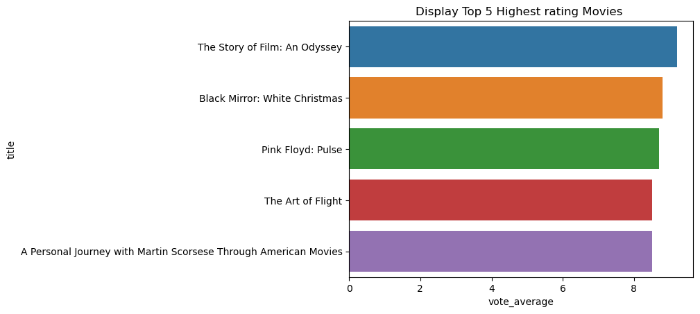

```python
sns.barplot(top_5_rating['vote_average'],top_5_rating.index)
plt.title("Display Top 5 Highest rating Movies ");
```

The Story of Film: An Odyssey in 2011 is the heighst vote avrage by 9.2

## Does Rating Affect The Profit?

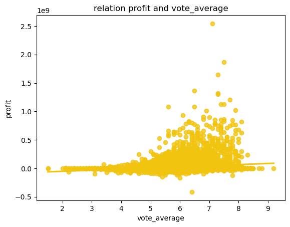

```python
sns.regplot(x='vote_average',y='profit',data=data ,color='#F1C40F');
plt.title('relation profit and vote_average');
```

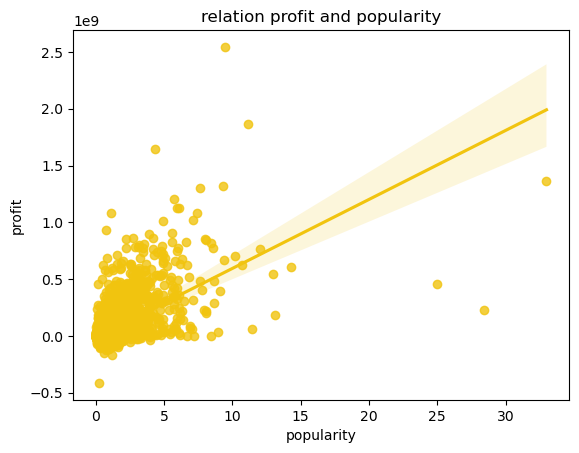

```python
sns.regplot(x='popularity',y='profit',data=data ,color='#F1C40F');
plt.title('relation profit and popularity')
```

## >>>>>>>>>>>>>>>>>>>>>>>>>>>>>>>>>>>>>>>>>>>>>>>>>>>

## Top 5 direcors produced Movies

## >>>>>>>>>>>>>>>>>>>>>>>>>>>>>>>>>>>>>>>>>>>>>>>>>>>

```python
Top_directors =data.director.value_counts().head()
Top_directors
```

```
Woody Allen         45
Clint Eastwood      34
Steven Spielberg    29
Martin Scorsese     28
Ridley Scott        23
Name: director, dtype: int64
```

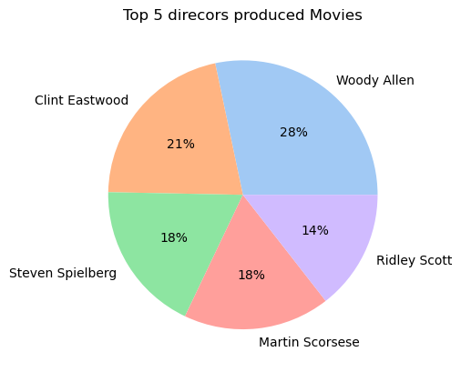

```python
plt.pie(Top_directors ,labels =Top_directors.index ,colors = colors, autopct='%.0f%%');
plt.title('Top 5 direcors produced Movies')
```

## >>>>>>>>>>>>>>>>>>>>>>>>>>>>>>>>>>>>>>>>>>>>>>>>>>>>>

Woody Allen

is the most director produced MOvies by 45 Movies 28%